# 🦉COSADAMA Introduction to Data Science Study

- 작성자: 박하람
- 참고자료: 파이썬 머신러닝 완벽가이드(권철민), 비쥬얼프로그래밍 수업(김승태), 파이썬으로 데이터 주무르기(민형기)

## [프로젝트] 서울시 구별 CCTV 현황 분석

이번 주차부터는 본격적으로 프로젝트를 통해 데이터 분석에 대한 기초 감각을 익히려 합니다. 직접 데이터를 다루면서 지난 시간에 학습한 pandas, numpy, matplotlib를 다루어보아야 확실하게 쓸 수 있더라구요. 그냥 보기만 하면 휘리릭 날아가 버립니다😅 오늘은 **서울시 구별 CCTV 현황 분석**을 해보려 합니다. 자잘한 것에 집중하기 보다 큰 그림을 보면서 이렇게 데이터 분석 과정이 이루어지는구나 라고 접근해주시면 좋을 것 같습니다.

**서울시 구별 CCTV 현황 분석**에서는 단순히 어디에서 CCTV가 많이 설치됐는지부터 시작해서 구별 인구 대비 비율을 확인하는 것까지 진행합니다. 특히 인구 현황을 보면서 구별 인구 현황도 확인하고, 구별 CCTV 현황을 시각화하는 것까지 해볼 겁니다. 이번 프로젝트를 통해서는 pandas와 Matplotlib의 기초를 배울 수 있습니다.

### 1. 문제 정의하기

본격적인 프로젝트에 앞서서 꼭 생각해봐야 할 중요한 지점이 있습니다. 우리는 판다스와 넘파이, 맷플랏립은 왜 배워야 할까요? 이 기술이 무엇에 필요한 걸까요? 무엇 때문에 우리가 이것을 이렇게 힘들게 배워야 하는 걸까요? 제 말은 결론적으로 배보다 배꼽이 크면 안된다라는 것을 말씀드리고 싶은 겁니다. 데이터를 분석하는 필요한 프로그래밍 지식들은 엄밀히 말하면 **도구**에 불과해요. 제일 선행되어야 하는 것은 **"내가 무엇을 해결하고 싶으냐? 무엇이 문제점이냐?"**입니다! 내가 어떠한 문제를 해결하고 싶다는 생각이 들면, 그 때부터 그 문제를 해결하기위해 **어떤 데이터를 수집**해야 하는지, 그 데이터를 어떻게 **가공**해야 할 것인지, 가공한 데이터를 어떻게 **분석하고 의미화할 것인지**, 그래서 나타난 결과가 **어떻게 문제를 해결**할 것인지를 알 수 있게 되는거죠.

이후에 머신러닝 프로젝트를 하더라도 마찬가지에요. 제가 지역별 건강 격차를 알고 싶어요, 그리고 그 건강 격차가 미래에 어떻게 될 지 예측을 해보고 싶어요. 그러면 우선 지역별 건강 격차를 드러낼 수 있는 데이터를 수집해야 해요. 아주 단순히 지역별 병원의 수라고 해봅시다. 그러면 지역별 병원의 수는 어떻게 구할 수 있는지부터 고민해야죠. 지역별 병원의 수를 구했으면 이 데이터를 어떻게 머신러닝에 맞게 가공을 해야 하는지, 또 나는 지역별 병원의 '수'를 예측하고 싶은데 그럼 또 어떤 알고리즘을 적용해야 할지 등등등 모든 것이 내가 알고 싶고 검증하고 싶은 **문제 정의**로부터 시작됩니다.

#### Q. 서울시 구별 CCTV 현황 분석을 하는 이유?

물론 제가 이 프로젝트를 한다고 하니까 분석하지만, 그 전에 그냥 상상해봅시다. 예를 들어 제가 (진짜 대충 생각한건데) '지역구가 부유할수록 CCTV를 더 많이 설치할 것이다.'라는 가설을 검증하고 싶어요. 오, 전체 대한민국은 너무 넓으니까 우선 서울시만 가지고 검증을 해봐야겠다, 이거 어디에서 데이터 구할 수 있지...? 아하, 서울 데이터 광장에서 구할 수 있구나! 그럼 또 뭐가 필요하지? 엇, CCTV 수만 가지고 이것을 제대로 검증할 수 있을까? 지역구의 땅이 넓어서 많이 설치하는 건 아닐까? 사람의 수가 많아서 많이 설치되어 있는 건 아닐까? 등등 여러가지 통제변수들도 생각해보면서 데이터로 검증해봐야겠다는 생각을 하는 겁니다.

### 2. 데이터 수집하기

그래서 결론적으로 여러분은 **서울시 자치구 연도별 CCTV 설치 현황**과 **서울인구** 공공데이터를 수집합니다. 서울인구 데이터는 지역구 인구 대비 CCTV 설치수까지 알아보려고 구하는 겁니다. 갑자기 과정이 생략되었는데요, 빈공간을 상상해보시고 이제 진짜로 프로젝트를 해보도록 하죠!

- [서울시 자치구 연도별 CCTV 설치 현황](https://data.seoul.go.kr/dataList/OA-2734/C/1/datasetView.do)
- [서울시 주민등록인구 통계](https://data.seoul.go.kr/dataList/419/S/2/datasetView.do)

주교재에 적힌 사이트와 현재 사이트가 달라지고 데이터도 개편되어서 위의 링크에서 다운받으려고 하면 그대로 따라할 수 없을 거에요. 그래서 저는 코사다마 구글 드라이브 week2 - 참고자료 폴더에 두개의 데이터를 넣어두었으니까 쓰시면 됩니다. 그래도 앞으로 써먹어야 하니까 위의 링크들 들어가셔서 이리저리 구경해보세요!

### 3. 데이터 가공하기

파일이 하나는 csv(콤마로 구분된 텍스트 파일)이고, 다른 하나는 엑셀입니다. 파이썬으로 이 둘을 모두 읽어볼 수 있는 방법을 익혀볼게요. pandas가 데이터 분석에 편리한 이유는 이렇게 단순한 코드 하나만으로 엑셀과 csv와 같이 다양한 파일을 읽어낼 수 있는 모듈을 가지고 있어요.

#### pandas와 numpy import하기

```python
import pandas as pd
import numpy as np
```

#### csv와 엑셀 파일 읽기

판다스와 넘파이를 임포트 해주고, 먼저는 서울시 자치구 연도별 CCTV 설치 현황 csv 파일부터 읽어봅니다.

- .read_csv()로 간단히 읽어낼 수 있습니다!

```python
CCTV_Seoul = pd.read_csv('01. CCTV_in_Seoul.csv',
                        encoding='UTF-8')
CCTV_Seoul.head()  # 데이터 앞의 5줄만 보여주세요!
```

|  | 기관명 | 소계 | 2013년도 이전 | 2014년 | 2015년 | 2016년 |
| --- | --- | --- | --- | --- | --- | --- |
| 0 | 강남구 | 2780 | 1292 | 430 | 584 | 932 |
| 1 | 강동구 | 773 | 379 | 99 | 155 | 377 |
| 2 | 강북구 | 748 | 369 | 120 | 138 | 204 |
| 3 | 강서구 | 884 | 388 | 258 | 184 | 81 |
| 4 | 관악구 | 1496 | 846 | 260 | 390 | 613 |

항상 데이터들을 살펴보는 것을 잊지마세요. 데이터가 무엇을 의미하는지도 중요하니까, 대충 아 강남구가 다른 곳에 비해서 많이 설치되어있네. 추이도 볼 수 있는데, 설치수가 줄어든 것도 보이고 늘어난 곳도 보이네요.

그런데 구의 column이름이 '기관명'으로 되어 있어서 이걸 '구별'로 바꿔볼게요!

```python
CCTV_Seoul.rename(columns={CCTV_Seoul.columns[0] : '구별'},
                  inplace=True)
CCTV_Seoul.head()
```

|  | 구별 | 소계 | 2013년도 이전 | 2014년 | 2015년 | 2016년 |
| --- | --- | --- | --- | --- | --- | --- |
| 0 | 강남구 | 2780 | 1292 | 430 | 584 | 932 |
| 1 | 강동구 | 773 | 379 | 99 | 155 | 377 |
| 2 | 강북구 | 748 | 369 | 120 | 138 | 204 |
| 3 | 강서구 | 884 | 388 | 258 | 184 | 81 |
| 4 | 관악구 | 1496 | 846 | 260 | 390 | 613 |

inplace=True 옵션을 쓸 때는 조심하기! 그럼 서울인구수가 담긴 엑셀 데이터도 읽어볼게요.

```python
pop_Seoul = pd.read_excel('01. population_in_Seoul.xls',
                          encoding='utf-8')
pop_Seoul.head()
```

|  | 기간 | 자치구 | 세대 | 인구 | 인구.1 | 인구.2 | 인구.3 | 인구.4 | 인구.5 | 인구.6 | 인구.7 | 인구.8 | 세대당인구 | 65세이상고령자 |
| --- | --- | --- | --- | --- | --- | --- | --- | --- | --- | --- | --- | --- | --- | --- |
| 0 | 기간 | 자치구 | 세대 | 합계 | 합계 | 합계 | 한국인 | 한국인 | 한국인 | 등록외국인 | 등록외국인 | 등록외국인 | 세대당인구 | 65세이상고령자 |
| 1 | 기간 | 자치구 | 세대 | 계 | 남자 | 여자 | 계 | 남자 | 여자 | 계 | 남자 | 여자 | 세대당인구 | 65세이상고령자 |
| 2 | 2017.1/4 | 합계 | 4202888 | 10197604 | 5000005 | 5197599 | 9926968 | 4871560 | 5055408 | 270636 | 128445 | 142191 | 2.36 | 1321458 |
| 3 | 2017.1/4 | 종로구 | 72654 | 162820 | 79675 | 83145 | 153589 | 75611 | 77978 | 9231 | 4064 | 5167 | 2.11 | 25425 |
| 4 | 2017.1/4 | 중구 | 59481 | 133240 | 65790 | 67450 | 124312 | 61656 | 62656 | 8928 | 4134 | 4794 | 2.09 | 20764 |

잉? 근데 column 제목들이 마음에 안들죠? index 1번째 줄에 있는 것으로 타이틀을 변경하고 싶고, 필요없는 데이터들을 모두 지우고 싶어요. 그럴 때는 아래와 같이 하라고 주교재에 나와 있습니다.

```python
# why isn't it working?
'''
pop_Seoul = pd.read_excel('01. population_in_Seoul.xls', header= 2, parse_cols = 'B, D, G, J, N', encoding='utf-8')
pop_Seoul.head()
'''
```

```
"\npop_Seoul = pd.read_excel('01. population_in_Seoul.xls', header= 2, parse_cols = 'B, D, G, J, N', encoding='utf-8')\npop_Seoul.head()\n"
```

이것을 프린트하면 에러가 떠요. 으잉, 이거 왜 안되는거야! 책이랑 똑같이 했는데! 판다스가 계속해서 업그레이드 하기 때문에 그래요. 그럴 때는 우리에게 치트키가 있잖아요?

```python
# If you want to know parameters you don't know, Here is a tip!
pd.read_excel?
```

```python
# Wow, it's working!
pop_Seoul = pd.read_excel('01. population_in_Seoul.xls',
                          header= 2,                       # header는 row 2번째줄로!
                          usecols = 'B, D, G, J, N',       # 요 columns만 가져온다!
                          inplace=True, encoding='utf-8')
pop_Seoul.head()
```

|  | 자치구 | 계 | 계.1 | 계.2 | 65세이상고령자 |
| --- | --- | --- | --- | --- | --- |
| 0 | 합계 | 10197604.0 | 9926968.0 | 270636.0 | 1321458.0 |
| 1 | 종로구 | 162820.0 | 153589.0 | 9231.0 | 25425.0 |
| 2 | 중구 | 133240.0 | 124312.0 | 8928.0 | 20764.0 |
| 3 | 용산구 | 244203.0 | 229456.0 | 14747.0 | 36231.0 |
| 4 | 성동구 | 311244.0 | 303380.0 | 7864.0 | 39997.0 |

이제 제대로 나왔네요. 그런데 columns 이름이 마음에 들지 않아요. 그리고 이 표를 잘 보세요. 우리가 나중에 구별 인구 대비 CCTV 설치수까지 비교를 해본다고 했잖아요. 그런데 CCTV 자료는 CCTV_Seoul에 있고, 서울인구 자료는 pop_Seoul에 있잖아요. 그러면 나중에 이 데이터를 합치게 될 거에요. 데이터를 합칠 때는 기준이 있는데, 저는 그 기준을 지역구로 하고 싶어요. 그래서 자치구를 '구별'로 바꿔주고 계, 계1, 계2, 65세이상고령자를 변수의 특성이 더 잘 나타나는 데이터로 바꾸어주고 싶어요. 그러면 아래와 같이 하면 됩니다!

```python
pop_Seoul = pop_Seoul.rename(columns={pop_Seoul.columns[0] : '구별',
                                      pop_Seoul.columns[1] : '인구수',
                                      pop_Seoul.columns[2] : '한국인',
                                      pop_Seoul.columns[3] : '외국인',
                                      pop_Seoul.columns[4] : '고령자'})
pop_Seoul.head()
```

|  | 구별 | 인구수 | 한국인 | 외국인 | 고령자 |
| --- | --- | --- | --- | --- | --- |
| 0 | 합계 | 10197604.0 | 9926968.0 | 270636.0 | 1321458.0 |
| 1 | 종로구 | 162820.0 | 153589.0 | 9231.0 | 25425.0 |
| 2 | 중구 | 133240.0 | 124312.0 | 8928.0 | 20764.0 |
| 3 | 용산구 | 244203.0 | 229456.0 | 14747.0 | 36231.0 |
| 4 | 성동구 | 311244.0 | 303380.0 | 7864.0 | 39997.0 |

책에는 이와 다르게 inplace 옵션을 사용하는데요, 저는 제 개인적인 취향은 inplace보다 이렇게 변수를 다시 정의해주는게 더 좋은 것 같더라구요. 본인이 원하는대로 하시면 됩니다.

그럼 이렇게 CSV와 엑셀 파일에 들어있는 데이터를 파이썬으로 불러오고, 정리까지 해보았습니다!

### 2.4 탐색적 데이터 분석하기

그럼 데이터를 잘 불러왔으니 데이터를 한번 살펴봐야겠죠?

```python
CCTV_Seoul.head()
```

|  | 구별 | 소계 | 2013년도 이전 | 2014년 | 2015년 | 2016년 |
| --- | --- | --- | --- | --- | --- | --- |
| 0 | 강남구 | 2780 | 1292 | 430 | 584 | 932 |
| 1 | 강동구 | 773 | 379 | 99 | 155 | 377 |
| 2 | 강북구 | 748 | 369 | 120 | 138 | 204 |
| 3 | 강서구 | 884 | 388 | 258 | 184 | 81 |
| 4 | 관악구 | 1496 | 846 | 260 | 390 | 613 |

#### 데이터 정렬하기

CCTV가 어디에 많이 있고 없는지를 알고 싶어요. 그러면 '소계'가 CCTV 수니까 이를 정렬시켜볼게요.

- .sort_values(by='기준 칼럼', ascending=True): 기준 칼럼을 기준으로 오름차순 정렬하기

```python
CCTV_Seoul.sort_values(by='소계', ascending=True).head(5)
```

|  | 구별 | 소계 | 2013년도 이전 | 2014년 | 2015년 | 2016년 |
| --- | --- | --- | --- | --- | --- | --- |
| 9 | 도봉구 | 485 | 238 | 159 | 42 | 386 |
| 12 | 마포구 | 574 | 314 | 118 | 169 | 379 |
| 17 | 송파구 | 618 | 529 | 21 | 68 | 463 |
| 24 | 중랑구 | 660 | 509 | 121 | 177 | 109 |
| 23 | 중구 | 671 | 413 | 190 | 72 | 348 |

데이터를 살펴보는 것이니 따로 변수에 담아줄 필요는 없어요. 보니까 도봉구, 마포구, 송파구, 중랑구, 중구가 CCTV 수로 하위 TOP5네요. 그리고 옆에 인덱스를 보면 구별에 따라서 인덱스가 적혀져 있어요. 이렇게 판다스는 고유한 인덱스가 변하지 않고 따라온다는 사실 덕분에 편하게 데이터를 가공할 수 있어요.

그리고 강남 3구 중의 하나인 송파구가 CCTV가 가장 적은 구 중의 하나라는 것인데, 강남 3구면 송파구에는 예산이 다른 구보다는 있지 않을까?(정확히 몰라요, 걍 생각해보는 것이라 검증을 해봐야지요) 👉 CCTV를 많이 설치할 수 있을 텐데..? 등의 이런 생각을 해볼 수 있겠죠. 이렇게 생각해 보는 과정이 **탐색적 데이터 분석** 과정입니다.

반대로 CCTV가 많이 설치되어 있는 TOP5 구들을 봅시다.

```python
CCTV_Seoul.sort_values(by='소계', ascending=False).head(5)
```

|  | 구별 | 소계 | 2013년도 이전 | 2014년 | 2015년 | 2016년 |
| --- | --- | --- | --- | --- | --- | --- |
| 0 | 강남구 | 2780 | 1292 | 430 | 584 | 932 |
| 18 | 양천구 | 2034 | 1843 | 142 | 30 | 467 |
| 14 | 서초구 | 1930 | 1406 | 157 | 336 | 398 |
| 21 | 은평구 | 1873 | 1138 | 224 | 278 | 468 |
| 20 | 용산구 | 1624 | 1368 | 218 | 112 | 398 |

상위 5구로는 강남구, 양천구, 서초구, 은평구, 용산구가 나오게 됩니다. 강남구와 서초구가 탑에 속해있으니, 내가 세운 가설이 맞을 수도 있겠군 등 이렇게 생각해보는 거죠..!

#### 데이터 연산하기

그 다음 살펴볼 것이 **3년간 CCTV 증가율**이에요. CCTV 데이터에 연도 데이터도 함께 있으니까 최근 증가율도 살펴볼 수 있어요.

- (최근 3년간 CCTV 증가율) = (2014년 + 2015년 + 2016년) / (2013년도 이전)* 100

```python
# 최근 3년간 CCTV 설치 증가율
CCTV_Seoul['최근증가율'] = ((CCTV_Seoul['2014년'] + CCTV_Seoul['2015년']
                       + CCTV_Seoul['2016년']) / CCTV_Seoul['2013년도 이전']) * 100
CCTV_Seoul.sort_values(by='최근증가율', ascending=False).head(5)
```

|  | 구별 | 소계 | 2013년도 이전 | 2014년 | 2015년 | 2016년 | 최근증가율 |
| --- | --- | --- | --- | --- | --- | --- | --- |
| 22 | 종로구 | 1002 | 464 | 314 | 211 | 630 | 248.922414 |
| 9 | 도봉구 | 485 | 238 | 159 | 42 | 386 | 246.638655 |
| 12 | 마포구 | 574 | 314 | 118 | 169 | 379 | 212.101911 |
| 8 | 노원구 | 1265 | 542 | 57 | 451 | 516 | 188.929889 |
| 1 | 강동구 | 773 | 379 | 99 | 155 | 377 | 166.490765 |

엇, 보니까 종로구가 정말 많이 증가했네요. 도봉구, 마포구도 그렇구요. 그럼 왜 이렇게 CCTV 설치율이 최근 사이에 늘어났을까도 사회학적으로 고민해볼 수 있겠죠!

#### 데이터 확인하기

- .unique(): 한번 이상 나타난 데이터를 알려줘요.

구별 칼럼에서 한 번 이상 나온 값이 무엇이 있을까 볼게요.

```python
pop_Seoul['구별'].unique()
```

```
array(['합계', '종로구', '중구', '용산구', '성동구', '광진구', '동대문구', '중랑구', '성북구',
       '강북구', '도봉구', '노원구', '은평구', '서대문구', '마포구', '양천구', '강서구', '구로구',
       '금천구', '영등포구', '동작구', '관악구', '서초구', '강남구', '송파구', '강동구', nan],
      dtype=object)
```

#### 결측치 처리하기

엇, 그런데 우리가 넘파이에서 배운 nan이 있어요. 이런 것을 결측치라고 합니다. **머신러닝을 돌릴 때나 데이터 분석을 할 때나 결측치가 있으면 예측이나 분석의 정확도가 떨어지고, 의도하지 않은 결과가 나올 수 있어요.** 그래서 이렇게 결측치가 있는 경우에는 NaN이 어디에 있는지를 알아서 **적절하게 처리**를 해줘야 해요.

```python
pop_Seoul[pop_Seoul['구별'].isnull()]
```

|  | 구별 | 인구수 | 한국인 | 외국인 | 고령자 |
| --- | --- | --- | --- | --- | --- |
| 26 | NaN | NaN | NaN | NaN | NaN |

```python
pop_Seoul.head()
```

|  | 구별 | 인구수 | 한국인 | 외국인 | 고령자 |
| --- | --- | --- | --- | --- | --- |
| 0 | 합계 | 10197604.0 | 9926968.0 | 270636.0 | 1321458.0 |
| 1 | 종로구 | 162820.0 | 153589.0 | 9231.0 | 25425.0 |
| 2 | 중구 | 133240.0 | 124312.0 | 8928.0 | 20764.0 |
| 3 | 용산구 | 244203.0 | 229456.0 | 14747.0 | 36231.0 |
| 4 | 성동구 | 311244.0 | 303380.0 | 7864.0 | 39997.0 |

아하, 이게 인덱스 26에만 있구나. 그리고 합계가 필요없어서 인덱스가 0, 26인 row를 지우려고 해요. 저는 결측치를 처리하는 방법으로 저는 이 데이터를 데이터에서 제거하기로 한거죠.

```python
pop_Seoul = pop_Seoul.drop([0, 26])
pop_Seoul.head(25)
```

|  | 구별 | 인구수 | 한국인 | 외국인 | 고령자 |
| --- | --- | --- | --- | --- | --- |
| 1 | 종로구 | 162820.0 | 153589.0 | 9231.0 | 25425.0 |
| 2 | 중구 | 133240.0 | 124312.0 | 8928.0 | 20764.0 |
| 3 | 용산구 | 244203.0 | 229456.0 | 14747.0 | 36231.0 |
| 4 | 성동구 | 311244.0 | 303380.0 | 7864.0 | 39997.0 |
| 5 | 광진구 | 372164.0 | 357211.0 | 14953.0 | 42214.0 |
| 6 | 동대문구 | 369496.0 | 354079.0 | 15417.0 | 54173.0 |
| 7 | 중랑구 | 414503.0 | 409882.0 | 4621.0 | 56774.0 |
| 8 | 성북구 | 461260.0 | 449773.0 | 11487.0 | 64692.0 |
| 9 | 강북구 | 330192.0 | 326686.0 | 3506.0 | 54813.0 |
| 10 | 도봉구 | 348646.0 | 346629.0 | 2017.0 | 51312.0 |
| 11 | 노원구 | 569384.0 | 565565.0 | 3819.0 | 71941.0 |
| 12 | 은평구 | 494388.0 | 489943.0 | 4445.0 | 72334.0 |
| 13 | 서대문구 | 327163.0 | 314982.0 | 12181.0 | 48161.0 |
| 14 | 마포구 | 389649.0 | 378566.0 | 11083.0 | 48765.0 |
| 15 | 양천구 | 479978.0 | 475949.0 | 4029.0 | 52975.0 |
| 16 | 강서구 | 603772.0 | 597248.0 | 6524.0 | 72548.0 |
| 17 | 구로구 | 447874.0 | 416487.0 | 31387.0 | 56833.0 |
| 18 | 금천구 | 255082.0 | 236353.0 | 18729.0 | 32970.0 |
| 19 | 영등포구 | 402985.0 | 368072.0 | 34913.0 | 52413.0 |
| 20 | 동작구 | 412520.0 | 400456.0 | 12064.0 | 56013.0 |
| 21 | 관악구 | 525515.0 | 507203.0 | 18312.0 | 68082.0 |
| 22 | 서초구 | 450310.0 | 445994.0 | 4316.0 | 51733.0 |
| 23 | 강남구 | 570500.0 | 565550.0 | 4950.0 | 63167.0 |
| 24 | 송파구 | 667483.0 | 660584.0 | 6899.0 | 72506.0 |
| 25 | 강동구 | 453233.0 | 449019.0 | 4214.0 | 54622.0 |

저는 inplace를 싫어해서 그냥 다시 변수를 정의해주었습니다. 이렇게 되니까 잘 제거되었는지 보고싶죠?

```python
pop_Seoul[pop_Seoul['구별'].isnull()]
```

|  | 구별 | 인구수 | 한국인 | 외국인 | 고령자 |
| --- | --- | --- | --- | --- | --- |

오, 없네요! 결측치를 잘 제거했습니다.

#### 데이터 탐색하기

이 작가는 고령자비율과 외국인비율을 계산했어요. 고령자비율과 외국인비율이 CCTV 설치율과 영향이 있는가 보고 싶은가봐요. 그러면 우리도 한번 고령자비율과 외국인 비율을 계산해볼게요!

```python
pop_Seoul['외국인비율'] = pop_Seoul['외국인'] / pop_Seoul['인구수'] * 100 #외국인비율 칼럼 생성
pop_Seoul['고령자비율'] = pop_Seoul['고령자'] / pop_Seoul['인구수'] * 100 #고령자비율 칼럼 생성
pop_Seoul.head()
```

|  | 구별 | 인구수 | 한국인 | 외국인 | 고령자 | 외국인비율 | 고령자비율 |
| --- | --- | --- | --- | --- | --- | --- | --- |
| 1 | 종로구 | 162820.0 | 153589.0 | 9231.0 | 25425.0 | 5.669451 | 15.615404 |
| 2 | 중구 | 133240.0 | 124312.0 | 8928.0 | 20764.0 | 6.700690 | 15.583909 |
| 3 | 용산구 | 244203.0 | 229456.0 | 14747.0 | 36231.0 | 6.038828 | 14.836427 |
| 4 | 성동구 | 311244.0 | 303380.0 | 7864.0 | 39997.0 | 2.526635 | 12.850689 |
| 5 | 광진구 | 372164.0 | 357211.0 | 14953.0 | 42214.0 | 4.017852 | 11.342849 |

이렇게 하면 데이터를 잘 알수 없으니까 또 오름차순과 내림차순을 해서 알아보도록 하죠.

```python
pop_Seoul.sort_values(by='인구수', ascending=False).head(5)
```

|  | 구별 | 인구수 | 한국인 | 외국인 | 고령자 | 외국인비율 | 고령자비율 |
| --- | --- | --- | --- | --- | --- | --- | --- |
| 24 | 송파구 | 667483.0 | 660584.0 | 6899.0 | 72506.0 | 1.033584 | 10.862599 |
| 16 | 강서구 | 603772.0 | 597248.0 | 6524.0 | 72548.0 | 1.080540 | 12.015794 |
| 23 | 강남구 | 570500.0 | 565550.0 | 4950.0 | 63167.0 | 0.867660 | 11.072217 |
| 11 | 노원구 | 569384.0 | 565565.0 | 3819.0 | 71941.0 | 0.670725 | 12.634883 |
| 21 | 관악구 | 525515.0 | 507203.0 | 18312.0 | 68082.0 | 3.484582 | 12.955291 |

인구수를 기준으로 내림차순을 해주면, 송파구가 인구가 제일 많네요!

```python
pop_Seoul.sort_values(by='외국인', ascending=False).head(5)
```

|  | 구별 | 인구수 | 한국인 | 외국인 | 고령자 | 외국인비율 | 고령자비율 |
| --- | --- | --- | --- | --- | --- | --- | --- |
| 19 | 영등포구 | 402985.0 | 368072.0 | 34913.0 | 52413.0 | 8.663598 | 13.006191 |
| 17 | 구로구 | 447874.0 | 416487.0 | 31387.0 | 56833.0 | 7.007998 | 12.689506 |
| 18 | 금천구 | 255082.0 | 236353.0 | 18729.0 | 32970.0 | 7.342345 | 12.925255 |
| 21 | 관악구 | 525515.0 | 507203.0 | 18312.0 | 68082.0 | 3.484582 | 12.955291 |
| 6 | 동대문구 | 369496.0 | 354079.0 | 15417.0 | 54173.0 | 4.172440 | 14.661322 |

외국인을 기준으로 하면, 영등포구에 외국인이 많이 살고 있군요!

```python
pop_Seoul.sort_values(by='외국인비율', ascending=False).head(5)
```

|  | 구별 | 인구수 | 한국인 | 외국인 | 고령자 | 외국인비율 | 고령자비율 |
| --- | --- | --- | --- | --- | --- | --- | --- |
| 19 | 영등포구 | 402985.0 | 368072.0 | 34913.0 | 52413.0 | 8.663598 | 13.006191 |
| 18 | 금천구 | 255082.0 | 236353.0 | 18729.0 | 32970.0 | 7.342345 | 12.925255 |
| 17 | 구로구 | 447874.0 | 416487.0 | 31387.0 | 56833.0 | 7.007998 | 12.689506 |
| 2 | 중구 | 133240.0 | 124312.0 | 8928.0 | 20764.0 | 6.700690 | 15.583909 |
| 3 | 용산구 | 244203.0 | 229456.0 | 14747.0 | 36231.0 | 6.038828 | 14.836427 |

외국인비율로도 보니까 영등포구가 제일이네요.

```python
pop_Seoul.sort_values(by='고령자', ascending=False).head(5)
```

|  | 구별 | 인구수 | 한국인 | 외국인 | 고령자 | 외국인비율 | 고령자비율 |
| --- | --- | --- | --- | --- | --- | --- | --- |
| 16 | 강서구 | 603772.0 | 597248.0 | 6524.0 | 72548.0 | 1.080540 | 12.015794 |
| 24 | 송파구 | 667483.0 | 660584.0 | 6899.0 | 72506.0 | 1.033584 | 10.862599 |
| 12 | 은평구 | 494388.0 | 489943.0 | 4445.0 | 72334.0 | 0.899091 | 14.631019 |
| 11 | 노원구 | 569384.0 | 565565.0 | 3819.0 | 71941.0 | 0.670725 | 12.634883 |
| 21 | 관악구 | 525515.0 | 507203.0 | 18312.0 | 68082.0 | 3.484582 | 12.955291 |

고령자 수자체로만 보면 강서구에 제일 많습니다.

```python
pop_Seoul.sort_values(by='고령자비율', ascending=False).head(5)
```

|  | 구별 | 인구수 | 한국인 | 외국인 | 고령자 | 외국인비율 | 고령자비율 |
| --- | --- | --- | --- | --- | --- | --- | --- |
| 9 | 강북구 | 330192.0 | 326686.0 | 3506.0 | 54813.0 | 1.061806 | 16.600342 |
| 1 | 종로구 | 162820.0 | 153589.0 | 9231.0 | 25425.0 | 5.669451 | 15.615404 |
| 2 | 중구 | 133240.0 | 124312.0 | 8928.0 | 20764.0 | 6.700690 | 15.583909 |
| 3 | 용산구 | 244203.0 | 229456.0 | 14747.0 | 36231.0 | 6.038828 | 14.836427 |
| 13 | 서대문구 | 327163.0 | 314982.0 | 12181.0 | 48161.0 | 3.723221 | 14.720797 |

고령자비율로만 보면 강북구에 많네요!

#### 데이터 병합하기

이렇게 데이터를 하나씩 보면서 인구 데이터와 CCTV 데이터의 특징을 살펴봤어요. 그런데 아직 우리는 인구 대비 CCTV 현황을 보지 못했죠? 이 데이터는 따로 존재하기 때문에 두 데이터를 병합해야 해요. 판다스에서 **merge()**를 배웠으니, 이것을 사용하여 데이터를 옆으로 병합해 보겠습니다.

```python
# data_result라는 새로운 변수에 담아줄게요!
data_result = pd.merge(CCTV_Seoul, pop_Seoul, on='구별')
data_result.head()
```

|  | 구별 | 소계 | 2013년도 이전 | 2014년 | 2015년 | 2016년 | 최근증가율 | 인구수 | 한국인 | 외국인 | 고령자 | 외국인비율 | 고령자비율 |
| --- | --- | --- | --- | --- | --- | --- | --- | --- | --- | --- | --- | --- | --- |
| 0 | 강남구 | 2780 | 1292 | 430 | 584 | 932 | 150.619195 | 570500.0 | 565550.0 | 4950.0 | 63167.0 | 0.867660 | 11.072217 |
| 1 | 강동구 | 773 | 379 | 99 | 155 | 377 | 166.490765 | 453233.0 | 449019.0 | 4214.0 | 54622.0 | 0.929765 | 12.051638 |
| 2 | 강북구 | 748 | 369 | 120 | 138 | 204 | 125.203252 | 330192.0 | 326686.0 | 3506.0 | 54813.0 | 1.061806 | 16.600342 |
| 3 | 강서구 | 884 | 388 | 258 | 184 | 81 | 134.793814 | 603772.0 | 597248.0 | 6524.0 | 72548.0 | 1.080540 | 12.015794 |
| 4 | 관악구 | 1496 | 846 | 260 | 390 | 613 | 149.290780 | 525515.0 | 507203.0 | 18312.0 | 68082.0 | 3.484582 | 12.955291 |

이제 앞에서 column이름은 구별로 공통적으로 처리했는지 아시겠죠? 두 데이터의 공통 컬럼인 '구별'로 merge를 하면 공통된 key를 가진 데이터만 남게 됩니다.

#### 데이터 삭제하기

그러면 이제 분석에 필요없는 칼럼들을 지워봅시다. 보니까 '2013년도 이전','2014년','2015년','2016년'은 필요하지 않네요! **drop()**을 사용하여 지워보겠습니다. (책에 나와있는 del 사용은 지양하길 권장합니다.) drop()은 기본이 axis=0이니까 column을 삭제하려면 axis=1로 해야겠네요!

```python
data_result = data_result.drop(['2013년도 이전','2014년','2015년','2016년'],1)
data_result.head()
```

|  | 구별 | 소계 | 최근증가율 | 인구수 | 한국인 | 외국인 | 고령자 | 외국인비율 | 고령자비율 |
| --- | --- | --- | --- | --- | --- | --- | --- | --- | --- |
| 0 | 강남구 | 2780 | 150.619195 | 570500.0 | 565550.0 | 4950.0 | 63167.0 | 0.867660 | 11.072217 |
| 1 | 강동구 | 773 | 166.490765 | 453233.0 | 449019.0 | 4214.0 | 54622.0 | 0.929765 | 12.051638 |
| 2 | 강북구 | 748 | 125.203252 | 330192.0 | 326686.0 | 3506.0 | 54813.0 | 1.061806 | 16.600342 |
| 3 | 강서구 | 884 | 134.793814 | 603772.0 | 597248.0 | 6524.0 | 72548.0 | 1.080540 | 12.015794 |
| 4 | 관악구 | 1496 | 149.290780 | 525515.0 | 507203.0 | 18312.0 | 68082.0 | 3.484582 | 12.955291 |

아, 판다스 너무 좋아요~💖 진짜 데이터 가공하기 너무 좋지 않나요,,, 감탄을 해야 합니다, 여러분ㅎㅎㅎ 코드 한줄로 이렇게 가공이 쉽다니,,,ㅠㅜ

#### 인덱스 만들기

후에 우리가 표로 시각화해서 나타낼 것인데요, 보통 표는 x축과 y축으로 되어있죠. 그래서 표를 나타날 때 인덱스와 컬럼명이 x나 y축으로 들어가게 되어요. (잘 이해가 안 간다면 넘어가시고 시각화를 한 다음 다시 돌아와보세요!) 그렇기 때문에 저는 index를 구 이름으로 바꾸어보겠습니다.

```python
data_result.set_index('구별', inplace=True)
data_result.head()
```

| 구별 | 소계 | 최근증가율 | 인구수 | 한국인 | 외국인 | 고령자 | 외국인비율 | 고령자비율 |
| --- | --- | --- | --- | --- | --- | --- | --- | --- |
| 강남구 | 2780 | 150.619195 | 570500.0 | 565550.0 | 4950.0 | 63167.0 | 0.867660 | 11.072217 |
| 강동구 | 773 | 166.490765 | 453233.0 | 449019.0 | 4214.0 | 54622.0 | 0.929765 | 12.051638 |
| 강북구 | 748 | 125.203252 | 330192.0 | 326686.0 | 3506.0 | 54813.0 | 1.061806 | 16.600342 |
| 강서구 | 884 | 134.793814 | 603772.0 | 597248.0 | 6524.0 | 72548.0 | 1.080540 | 12.015794 |
| 관악구 | 1496 | 149.290780 | 525515.0 | 507203.0 | 18312.0 | 68082.0 | 3.484582 | 12.955291 |

#### 상관계수 분석

우리는 간단한 상관계수 분석을 해볼거에요. 상관관계는 관계를 알고자 하는 두 변수가 모두 연속변수일 경우에만 계산이 가능하고, 이는 인과관계를 분석하는게 아닌 두 연속변수가 관련이 있는지 없는지를 알아보는 기술통계 분석이에요. 두 변수를 x,y라고 하면 상관관계 계수(coefficient)는 x값과 y값을 모두 z값으로 표준화해서 Zx * Zy를 모두 더한다음, n(총 개수)으로 나눠준 것이 상관계수에요. 다른 것은 다됐고 여기서 상관계수는 넘파이가 다 계산해 줄 테니까 우리는 여기서 **상관계수가 무엇을 의미**하는지만 알면 돼요!

- 0 ~ 0.2 : 매우 약한 상관관계
- 0.2 ~ 0.4 : 약한 상관관계
- 0.4 ~ 0.6 : 어느 정도의 상관관계
- 0.6 ~ 0.8 : 강한 상관관계
- 0.8 ~ 1.0 : 매우 강한 상관관계

상관계수의 범위는 -1부터 1까지 음수가 나오면 음의 상관관계, 양수가 나오면 양의 상관관계라는 것까지만 알면 됩니다.

그럼 다수의 데이터 중 상관계수가 가장 큰 값은 데이터를 비교해볼게요. **numpy의 corrcoef 명령**을 사용하면 상관계수를 알아서 계산해줍니다.

```python
# 약한 음의 상관관계
np.corrcoef(data_result['고령자비율'], data_result['소계'])
```

```
array([[ 1.        , -0.28078554],
       [-0.28078554,  1.        ]])
```

```python
# 상관관계가 거의 없다고 할 수 있음.
np.corrcoef(data_result['외국인비율'], data_result['소계'])
```

```
array([[ 1.        , -0.13607433],
       [-0.13607433,  1.        ]])
```

```python
# 0.3이어서 약한 상관관계
np.corrcoef(data_result['인구수'], data_result['소계'])
```

```
array([[1.        , 0.30634228],
       [0.30634228, 1.        ]])
```

엇, 보니까 외국인비율은 거의 상관관계가 없다고 할 수 있고, 여기서 그래도 유의미한 것은 '인구수'네요! 그럼 CCTV와 인구수의 관계를 더 들여다볼게요!

```python
data_result.sort_values(by='소계', ascending=False).head(5)
```

| 구별 | 소계 | 최근증가율 | 인구수 | 한국인 | 외국인 | 고령자 | 외국인비율 | 고령자비율 |
| --- | --- | --- | --- | --- | --- | --- | --- | --- |
| 강남구 | 2780 | 150.619195 | 570500.0 | 565550.0 | 4950.0 | 63167.0 | 0.867660 | 11.072217 |
| 양천구 | 2034 | 34.671731 | 479978.0 | 475949.0 | 4029.0 | 52975.0 | 0.839413 | 11.036964 |
| 서초구 | 1930 | 63.371266 | 450310.0 | 445994.0 | 4316.0 | 51733.0 | 0.958451 | 11.488308 |
| 은평구 | 1873 | 85.237258 | 494388.0 | 489943.0 | 4445.0 | 72334.0 | 0.899091 | 14.631019 |
| 용산구 | 1624 | 53.216374 | 244203.0 | 229456.0 | 14747.0 | 36231.0 | 6.038828 | 14.836427 |

오호라, 여기에서 가장 CCTV가 많이 설치된 구는 강남구, 양천구, 서초구 순이네요. 그럼 인구수를 한번 볼까요?

```python
data_result.sort_values(by='인구수', ascending=False).head(5)
```

| 구별 | 소계 | 최근증가율 | 인구수 | 한국인 | 외국인 | 고령자 | 외국인비율 | 고령자비율 |
| --- | --- | --- | --- | --- | --- | --- | --- | --- |
| 송파구 | 618 | 104.347826 | 667483.0 | 660584.0 | 6899.0 | 72506.0 | 1.033584 | 10.862599 |
| 강서구 | 884 | 134.793814 | 603772.0 | 597248.0 | 6524.0 | 72548.0 | 1.080540 | 12.015794 |
| 강남구 | 2780 | 150.619195 | 570500.0 | 565550.0 | 4950.0 | 63167.0 | 0.867660 | 11.072217 |
| 노원구 | 1265 | 188.929889 | 569384.0 | 565565.0 | 3819.0 | 71941.0 | 0.670725 | 12.634883 |
| 관악구 | 1496 | 149.290780 | 525515.0 | 507203.0 | 18312.0 | 68082.0 | 3.484582 | 12.955291 |

아하, 인구수로 보니 송파구, 강서구, 강남구 순으로 인구수가 많네요.

### 2.5 matplotlib으로 시각화하기

우리 결과들을 더 직관적으로 보기 위해서 matplotlib를 사용하여 그래프로 만들어봅시다. 어떤 그래프를 선택할 것이냐는 데이터에 따라서 달라져요. **데이터의 특성을 잘 나타낼 수 있는 그래프를 선택할 수 있어야 합니다.** 그래서 앞서서 데이터를 쭈욱 살펴봤던 것이 그래서 매우 중요해요. 아니면 반대로 데이터의 특성을 잘 모르겠을 때, 시각화해서 표로 표시한다면 데이터의 특성을 좀 더 잘 알게 되기도 합니다. (이것은 나중에 더 설명해보기로 하구요🐼)

우선, matplotlib를 inline으로 깔아주고, 표에 한글이 나올 수 있도록 복붙만 해봅시다.

```python
import matplotlib.pyplot as plt
%matplotlib inline
```

```python
import platform

from matplotlib import font_manager, rc
plt.rcParams['axes.unicode_minus'] = False

if platform.system() == 'Darwin':
    rc('font', family='AppleGothic')
elif platform.system() == 'Windows':
    path = "c:/Windows/Fonts/malgun.ttf"
    font_name = font_manager.FontProperties(fname=path).get_name()
    rc('font', family=font_name)
else:
    print('Unknown system')
```

```python
data_result.head()
```

| 구별 | 소계 | 최근증가율 | 인구수 | 한국인 | 외국인 | 고령자 | 외국인비율 | 고령자비율 |
| --- | --- | --- | --- | --- | --- | --- | --- | --- |
| 강남구 | 2780 | 150.619195 | 570500.0 | 565550.0 | 4950.0 | 63167.0 | 0.867660 | 11.072217 |
| 강동구 | 773 | 166.490765 | 453233.0 | 449019.0 | 4214.0 | 54622.0 | 0.929765 | 12.051638 |
| 강북구 | 748 | 125.203252 | 330192.0 | 326686.0 | 3506.0 | 54813.0 | 1.061806 | 16.600342 |
| 강서구 | 884 | 134.793814 | 603772.0 | 597248.0 | 6524.0 | 72548.0 | 1.080540 | 12.015794 |
| 관악구 | 1496 | 149.290780 | 525515.0 | 507203.0 | 18312.0 | 68082.0 | 3.484582 | 12.955291 |

##### bar 그래프 그리기

우선, 직관적으로 구별 CCTV 설치수를 알고 싶어요. 그래서 저는 **바 그래프**를 한번 선택해보았습니다.

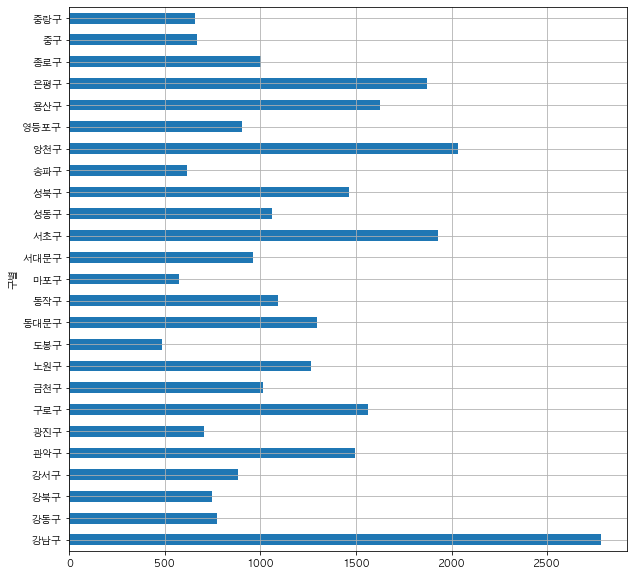

```python
data_result['소계'].plot(kind='barh', grid=True, figsize=(10,10))
plt.show()
```

숫자만 볼 때보다는 나은데 그래도 뒤죽박죽하니 정렬하면 더 잘 알수 있겠죠.

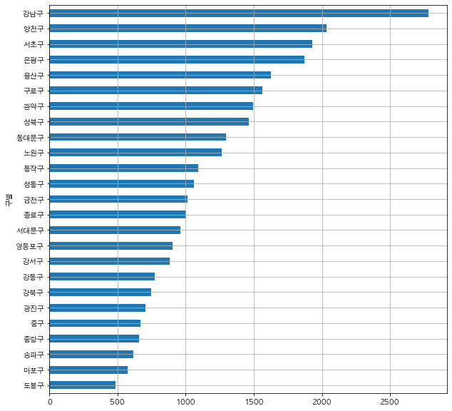

```python
data_result['소계'].sort_values().plot(kind='barh', grid=True, figsize=(10,10))
plt.show()
```

이렇게 sort_values()를 메서드 체이닝으로 연결해주어 정렬해줍니다. 와, 이렇게 bar 그래프로 보니까 강남구가 정말 많기는 많네요..! 그리고 그리드를 설정해줘서 강남구가 도봉구의 5배 이상이 된다는 것 또한 쉽게 알 수 있네요. 보니까 강남구가 월등하게 CCTV 설치수가 많고, 그 다음에는 양천구, 서초구, 은평구 순으로 많습니다. 가장 수가 적은 곳은 도봉구이고, 중구, 중랑구, 송파구, 마포구가 CCTV 설치수가 상대적으로 낮은 곳이네요.

그렇지만 CCTV 수가 많은 것만 보면 안되죠. 지역구가 다른 곳에 비해 상대적으로 넓다거나, 인구 수가 많아서 CCTV를 더 많이 설치했을 수도 있잖아요. 그래서 우리는 인구 대비 CCTV 비율을 계산해서 다시 시각화해볼게요.

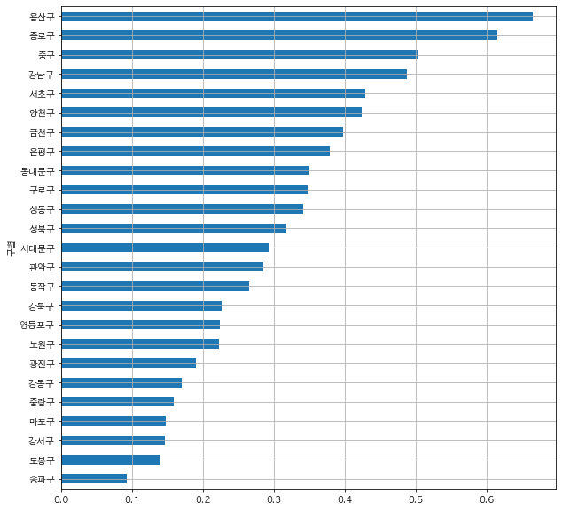

```python
data_result['CCTV비율'] = data_result['소계'] / data_result['인구수'] * 100
data_result['CCTV비율'].sort_values().plot(kind='barh', grid=True, figsize=(10,10))

plt.show()
```

오, 보니까 용산구는 CCTV 수도 상위였지만 인구 대비 수로 보면 월등하네요. 종로구는 CCTV 수로는 중위정도 됐는데, 인구 대비 비율로는 상위권에 속해네요ㅎㅎ 오, 시각화 하니까 이런 것까지 알 수 있네요!

##### 산점도 그리기

그러면 나아가서 인구수와 CCTV 수를 산점도로 그려볼게요. **scatter**를 사용하면 산점도를 그릴 수 있고, s는 마커의 크기입니다.(마커가 뭔지 모른다면 숫자를 늘렸다 줄였다 해보세요!)

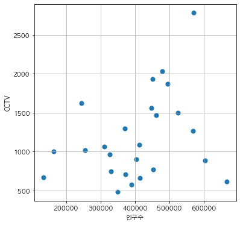

```python
plt.figure(figsize=(6,6))
plt.scatter(data_result['인구수'], data_result['소계'], s=50)
plt.xlabel('인구수')
plt.ylabel('CCTV')
plt.grid()
plt.show()
```

각각의 코드가 무엇을 의미하는지 모른다면 matplotlib의 scatter를 좀더 보고오세요^^ 인구수를 보면 x축이 100,000부터 시작해 700,000까지 있죠? 기억해두시면 이따가 추세선 그릴 때 또 쓰일 거에요.

##### 추세선 그리기 - 선형 회귀선

(사회통계론을 듣지 않았거나 이 부분을 읽어도 이해가 가지 않는다면, 코드만 복붙해서 실행해보고 넘어가면 됩니다!)

오, 이제는 여기에 대충 경향을 보고 싶어요. 아까 상관계수가 어느 정도 약하게 있다고 나왔잖아요. 그래서 요 데이터를 가지고 경향성을 나타낼 수 있는 하나의 직선을 만들어줄 겁니다. 우리가 넘파이 실습과제에서 하나의 선을 그렸듯이 넘파이의 **polyfit 함수**를 사용해서 만들어줄 거에요. polyfit()은 **n차 다항식으로 회귀분석을 할 때 사용하는 함수**에요.

- np.polyfit(x, y, n): x는 x에 들어갈 데이터, y는 y에 들어갈 데이터, n는 다항식의 차수

우리가 그리고 싶은 추세선은 직선이라 y=ax+b라고 하죠. 직선은 1차원이니까 n=1이고, polyfit의 결과값은 [a,b]가 나오게 되어요. 즉, 기울기와 절편값이 나오는거죠. 우리가 사통론에서 요 a,b값을 구하려고, 일일이 하나씩 다 계산해서 정말 힘들게 계산했잖아요. 그런데 이렇게 polyfit()을 사용하면 바로 기울기와 절편값을 줍니다. 2,3,4 등 n차원까지 모두 가능해요.

```python
fp1 = np.polyfit(data_result['인구수'], data_result['소계'],1)
fp1
```

```
array([1.30916415e-03, 6.45066497e+02])
```

그럼 이건 주어진 데이터를 가지고 만들어낸 1차 방정식의 기울기와 절편값이에요. 그 다음에는 **poly1d()**를 가지고 직선을 만들어볼게요.

- [poly1d()란?](https://docs.scipy.org/doc/numpy/reference/generated/numpy.poly1d.html)

이것을 보시고 이해를 해보세요. poly1d는 다항식(polynomial function)을 정의해주는 함수에요. 즉, 우리가 poly1d() 안에 [a,b]를 넣는다면, ax+b라는 1차 방정식을 넣어주는거죠. 만약 poly1d([1,2,3])이라면 x^2+2x+3을 만들어주는 것이구요.

```python
f1 = np.poly1d(fp1)
```

[output not shown]

f1 자체가 방정식이니까, 직선을 만드려면 x값을 공급해줘야해요. 그 x값은 **np.linspace**로 만들어 줄 거에요.

- np.linspace(start, stop, num): num은 데이터 개수

np.linspace 함수는 start부터 stop의 범위에서 num개를 균일한 간격으로 데이터를 생성하고 배열을 만드는 함수에요.

```python
fx = np.linspace(100000, 700000, 100)
```

그러니까 정리를 하면, x에는 fx를 공급해주고, y로는 다항식을 만들어 준 f1을 넣어주는 것이죠. 그래서 점선의 일차원 그래프를 만들어보면!

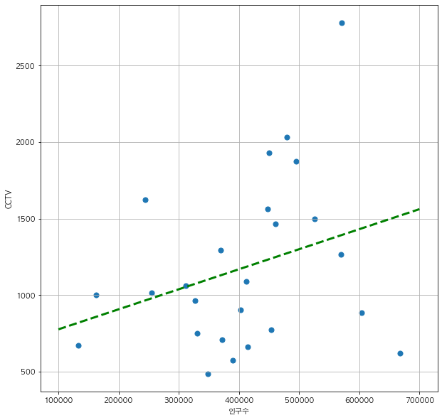

```python
plt.figure(figsize=(10,10))
plt.scatter(data_result['인구수'], data_result['소계'], s=50)
plt.plot(fx, f1(fx), ls='dashed', lw=3, color='g')
plt.xlabel('인구수')
plt.ylabel('CCTV')
plt.grid()
plt.show()
```

이렇게 추세선 완성! 오, CCTV와 인구수에 이런 추세선이 그려지는 군요.

여기에다가 저자는 두 가지 장치를 더했어요. 하나는 직선의 경향에서 멀어진 구일수록 색이 변한다는 것과, 다른 하나는 경향에서 멀어진 구의 이름을 표시하고 싶다는 거에요. 그래서 이를 표시하기위해 오차를 계산하는 코드를 만들었어요.

- 오차 = |(CCTV수) - f1(인구수)|

엇, 이거 우리 회귀분석할 때 선형 회귀식을 만들 때 봤죠? 아까 우리가 추세선을 만들었잖아요. 그 추세선이 바로 **회귀식**이랍니다. **오차는 회귀선을 통해서 나온 y값과 실제 y값의 차이**잖아요. 그래서 요거를 이용해서 오차를 계산해 data_result에다 새로운 컬럼으로 넣어주어봤습니다.

```python
fp1 = np.polyfit(data_result['인구수'], data_result['소계'],1)

f1 = np.poly1d(fp1)
fx = np.linspace(100000, 700000, 100)

# 오차 칼럼 만들어주기
data_result['오차'] = np.abs(data_result['소계'] - f1(data_result['인구수']))
data_result.head()
```

| 구별 | 소계 | 최근증가율 | 인구수 | 한국인 | 외국인 | 고령자 | 외국인비율 | 고령자비율 | CCTV비율 | 오차 |
| --- | --- | --- | --- | --- | --- | --- | --- | --- | --- | --- |
| 강남구 | 2780 | 150.619195 | 570500.0 | 565550.0 | 4950.0 | 63167.0 | 0.867660 | 11.072217 | 0.487292 | 1388.055355 |
| 강동구 | 773 | 166.490765 | 453233.0 | 449019.0 | 4214.0 | 54622.0 | 0.929765 | 12.051638 | 0.170552 | 465.422892 |
| 강북구 | 748 | 125.203252 | 330192.0 | 326686.0 | 3506.0 | 54813.0 | 1.061806 | 16.600342 | 0.226535 | 329.342026 |
| 강서구 | 884 | 134.793814 | 603772.0 | 597248.0 | 6524.0 | 72548.0 | 1.080540 | 12.015794 | 0.146413 | 551.503155 |
| 관악구 | 1496 | 149.290780 | 525515.0 | 507203.0 | 18312.0 | 68082.0 | 3.484582 | 12.955291 | 0.284673 | 162.948104 |

그럼 이것을 '오차'를 기준으로 데이터를 정렬해보도록 할게요.

```python
df_sort = data_result.sort_values(by='오차', ascending=False)
df_sort.head()
```

| 구별 | 소계 | 최근증가율 | 인구수 | 한국인 | 외국인 | 고령자 | 외국인비율 | 고령자비율 | CCTV비율 | 오차 |
| --- | --- | --- | --- | --- | --- | --- | --- | --- | --- | --- |
| 강남구 | 2780 | 150.619195 | 570500.0 | 565550.0 | 4950.0 | 63167.0 | 0.867660 | 11.072217 | 0.487292 | 1388.055355 |
| 송파구 | 618 | 104.347826 | 667483.0 | 660584.0 | 6899.0 | 72506.0 | 1.033584 | 10.862599 | 0.092587 | 900.911312 |
| 양천구 | 2034 | 34.671731 | 479978.0 | 475949.0 | 4029.0 | 52975.0 | 0.839413 | 11.036964 | 0.423769 | 760.563512 |
| 서초구 | 1930 | 63.371266 | 450310.0 | 445994.0 | 4316.0 | 51733.0 | 0.958451 | 11.488308 | 0.428594 | 695.403794 |
| 용산구 | 1624 | 53.216374 | 244203.0 | 229456.0 | 14747.0 | 36231.0 | 6.038828 | 14.836427 | 0.665020 | 659.231690 |

그럼 이제 텍스트와 color map을 입혀볼게요.

- color는 plt.scatter()의 c 옵션값으로 넣어줬어요.
- plt.text(x, y, s): x와 y는 (x,y)위치(the position to place the text), s는 넣어줄 텍스트(the text)

우리 파이썬을 배웠기 때문에 아래의 for문 이해할 수 있어요💖

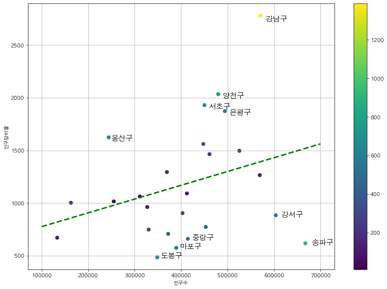

```python
plt.figure(figsize=(14,10))
plt.scatter(data_result['인구수'], data_result['소계'],
           c=data_result['오차'], s=50)                   #c=marker color, s=marker size
plt.plot(fx, f1(fx), ls='dashed', lw=3, color='g')       #lw=line width

# 텍스트 만들어주기
for n in range(10):
    plt.text(df_sort['인구수'][n]*1.02, df_sort['소계'][n]*0.98,
            df_sort.index[n], fontsize=15)

plt.xlabel('인구수')
plt.ylabel('인구당비율')

plt.colorbar()
plt.grid()
plt.show()
```

df_sort는 오차가 높은 순으로 배열을 해놓았죠. 그래서 for문을 사용해 range(10), 즉 상위 10개만 text를 보이도록 해줬어요.

- df_sort['인구수'][n]*1.02, df_sort['소계'][n]*0.98

이렇게 적은 이유는 점의 바로 위에 이름이 올라가게 하지 말고, 오른쪽으로 이름이 위치할 수 있도록 한거에요. 이름이 위치한 곳이 모두 다 오른쪽 살짝 옆에 있죠? 이것을 for문으로 구현한 것이랍니다.

### 2.5 분석 결과

직선을 기준으로 위에 있는 '강남구', '양천구', '서초구', '은평구', '용산구'는 서울시 전체 지역의 일반적인 경향보다 CCTV가 많이 설치된 지역이네요. 그리고 '송파구','강서구','중랑구','마포구','도봉구'는 일반적인 경향보다 CCTV가 적게 설치된 지역이고요. 특히 '강남구'는 월등히 많은 CCTV가 설치됐지만, '송파구'는 인구수에 비해 너무나도 적은 수의 CCTV를 가지고 있네요!

여기다 이제 우리는 사회학하는 친구들이니까 왜 이렇게 될까를 생각해봐야겠죠. 앞서 처음에 생각했던 '구별 예산 정도에 따라 CCTV 설치수가 다를꺼다'라는 것을 증명할 수는 없지만(예산 데이터가 없으니까요), 왜 저렇게 강남구는 아웃라이어로 있나라고 생각해볼 수 있겠죠 😊

## 프로젝트를 끝내며

축하합니다, 여러분! 드디어 하나의 프로젝트가 끝이 났어요!!! (이틀째 꼴딱 새고 이 교안을 만들었는데, 드디어 만들었어요ㅎㅎ)

이렇게 첫번째 프로젝트를 해보았네요. 끝에 추세선 만들기에서 많이 어려웠을 것 같은데, 최대한 이해를 해보시고 안되면 넘어가세요. 괜히 압도되지 말고 할 수 있는 것을 챙겨서 하면 된답니다💕 전체 과정을 한번 쭉 보세요. 거시적으로 보면서 하나하나씩 세부적으로 들어가면 왜 이 코드를 작성하고 있는지 알 수 있게 됩니다. 여러분에게 많이 도움이 되었길 바라구요. 모두모두 고생했습니다💗